# Analyzing Student Dropouts

## Imports

```python
import pandas as pd
import matplotlib.pyplot as plt
import numpy as np
from ucimlrepo import fetch_ucirepo
from sklearn.preprocessing import StandardScaler
from sklearn.decomposition import PCA
import Helper
from sklearn.metrics import accuracy_score
from xgboost import XGBClassifier
from sklearn.model_selection import train_test_split
from sklearn.ensemble import RandomForestClassifier
```

## Loading and exploring the data

```python
# fetch dataset
predict_students_dropout_and_academic_success = fetch_ucirepo(id=697)
```

```python
# Get the original dataset
student_data = predict_students_dropout_and_academic_success.data.original.copy()

# metadata
meta_data = predict_students_dropout_and_academic_success.variables

student_data.head()
```

|  | Marital Status | Application mode | Application order | Course | Daytime/evening attendance | Previous qualification | Previous qualification (grade) | Nacionality | Mother's qualification | Father's qualification | ... | Curricular units 2nd sem (credited) | Curricular units 2nd sem (enrolled) | Curricular units 2nd sem (evaluations) | Curricular units 2nd sem (approved) | Curricular units 2nd sem (grade) | Curricular units 2nd sem (without evaluations) | Unemployment rate | Inflation rate | GDP | Target |
| --- | --- | --- | --- | --- | --- | --- | --- | --- | --- | --- | --- | --- | --- | --- | --- | --- | --- | --- | --- | --- | --- |
| 0 | 1 | 17 | 5 | 171 | 1 | 1 | 122.0 | 1 | 19 | 12 | ... | 0 | 0 | 0 | 0 | 0.000000 | 0 | 10.8 | 1.4 | 1.74 | Dropout |
| 1 | 1 | 15 | 1 | 9254 | 1 | 1 | 160.0 | 1 | 1 | 3 | ... | 0 | 6 | 6 | 6 | 13.666667 | 0 | 13.9 | -0.3 | 0.79 | Graduate |
| 2 | 1 | 1 | 5 | 9070 | 1 | 1 | 122.0 | 1 | 37 | 37 | ... | 0 | 6 | 0 | 0 | 0.000000 | 0 | 10.8 | 1.4 | 1.74 | Dropout |
| 3 | 1 | 17 | 2 | 9773 | 1 | 1 | 122.0 | 1 | 38 | 37 | ... | 0 | 6 | 10 | 5 | 12.400000 | 0 | 9.4 | -0.8 | -3.12 | Graduate |
| 4 | 2 | 39 | 1 | 8014 | 0 | 1 | 100.0 | 1 | 37 | 38 | ... | 0 | 6 | 6 | 6 | 13.000000 | 0 | 13.9 | -0.3 | 0.79 | Graduate |

5 rows × 37 columns

```python
student_data.dtypes
```

```
Marital Status                                      int64
Application mode                                    int64
Application order                                   int64
Course                                              int64
Daytime/evening attendance                          int64
Previous qualification                              int64
Previous qualification (grade)                    float64
Nacionality                                         int64
Mother's qualification                              int64
Father's qualification                              int64
Mother's occupation                                 int64
Father's occupation                                 int64
Admission grade                                   float64
Displaced                                           int64
Educational special needs                           int64
Debtor                                              int64
Tuition fees up to date                             int64
Gender                                              int64
Scholarship holder                                  int64
Age at enrollment                                   int64
International                                       int64
Curricular units 1st sem (credited)                 int64
Curricular units 1st sem (enrolled)                 int64
Curricular units 1st sem (evaluations)              int64
Curricular units 1st sem (approved)                 int64
Curricular units 1st sem (grade)                  float64
Curricular units 1st sem (without evaluations)      int64
Curricular units 2nd sem (credited)                 int64
Curricular units 2nd sem (enrolled)                 int64
Curricular units 2nd sem (evaluations)              int64
Curricular units 2nd sem (approved)                 int64
Curricular units 2nd sem (grade)                  float64
Curricular units 2nd sem (without evaluations)      int64
Unemployment rate                                 float64
Inflation rate                                    float64
GDP                                               float64
Target                                             object
dtype: object
```

```python
meta_data
```

|  | name | role | type | demographic | description | units | missing_values |
| --- | --- | --- | --- | --- | --- | --- | --- |
| 0 | Marital Status | Feature | Integer | Marital Status | 1 – single 2 – married 3 – widower 4 – divorce... | None | no |
| 1 | Application mode | Feature | Integer | None | 1 - 1st phase - general contingent 2 - Ordinan... | None | no |
| 2 | Application order | Feature | Integer | None | Application order (between 0 - first choice; a... | None | no |
| 3 | Course | Feature | Integer | None | 33 - Biofuel Production Technologies 171 - Ani... | None | no |
| 4 | Daytime/evening attendance | Feature | Integer | None | 1 – daytime 0 - evening | None | no |
| 5 | Previous qualification | Feature | Integer | Education Level | 1 - Secondary education 2 - Higher education -... | None | no |
| 6 | Previous qualification (grade) | Feature | Continuous | None | Grade of previous qualification (between 0 and... | None | no |
| 7 | Nacionality | Feature | Integer | Nationality | 1 - Portuguese; 2 - German; 6 - Spanish; 11 - ... | None | no |
| 8 | Mother's qualification | Feature | Integer | Education Level | 1 - Secondary Education - 12th Year of Schooli... | None | no |
| 9 | Father's qualification | Feature | Integer | Education Level | 1 - Secondary Education - 12th Year of Schooli... | None | no |
| 10 | Mother's occupation | Feature | Integer | Occupation | 0 - Student 1 - Representatives of the Legisla... | None | no |
| 11 | Father's occupation | Feature | Integer | Occupation | 0 - Student 1 - Representatives of the Legisla... | None | no |
| 12 | Admission grade | Feature | Continuous | None | Admission grade (between 0 and 200) | None | no |
| 13 | Displaced | Feature | Integer | None | 1 – yes 0 – no | None | no |
| 14 | Educational special needs | Feature | Integer | None | 1 – yes 0 – no | None | no |
| 15 | Debtor | Feature | Integer | None | 1 – yes 0 – no | None | no |
| 16 | Tuition fees up to date | Feature | Integer | None | 1 – yes 0 – no | None | no |
| 17 | Gender | Feature | Integer | Gender | 1 – male 0 – female | None | no |
| 18 | Scholarship holder | Feature | Integer | None | 1 – yes 0 – no | None | no |
| 19 | Age at enrollment | Feature | Integer | Age | Age of studend at enrollment | None | no |
| 20 | International | Feature | Integer | None | 1 – yes 0 – no | None | no |
| 21 | Curricular units 1st sem (credited) | Feature | Integer | None | Number of curricular units credited in the 1st... | None | no |
| 22 | Curricular units 1st sem (enrolled) | Feature | Integer | None | Number of curricular units enrolled in the 1st... | None | no |
| 23 | Curricular units 1st sem (evaluations) | Feature | Integer | None | Number of evaluations to curricular units in t... | None | no |
| 24 | Curricular units 1st sem (approved) | Feature | Integer | None | Number of curricular units approved in the 1st... | None | no |
| 25 | Curricular units 1st sem (grade) | Feature | Integer | None | Grade average in the 1st semester (between 0 a... | None | no |
| 26 | Curricular units 1st sem (without evaluations) | Feature | Integer | None | Number of curricular units without evalutions ... | None | no |
| 27 | Curricular units 2nd sem (credited) | Feature | Integer | None | Number of curricular units credited in the 2nd... | None | no |
| 28 | Curricular units 2nd sem (enrolled) | Feature | Integer | None | Number of curricular units enrolled in the 2nd... | None | no |
| 29 | Curricular units 2nd sem (evaluations) | Feature | Integer | None | Number of evaluations to curricular units in t... | None | no |
| 30 | Curricular units 2nd sem (approved) | Feature | Integer | None | Number of curricular units approved in the 2nd... | None | no |
| 31 | Curricular units 2nd sem (grade) | Feature | Integer | None | Grade average in the 2nd semester (between 0 a... | None | no |
| 32 | Curricular units 2nd sem (without evaluations) | Feature | Integer | None | Number of curricular units without evalutions ... | None | no |
| 33 | Unemployment rate | Feature | Continuous | None | Unemployment rate (%) | None | no |
| 34 | Inflation rate | Feature | Continuous | None | Inflation rate (%) | None | no |
| 35 | GDP | Feature | Continuous | None | GDP | None | no |
| 36 | Target | Target | Categorical | None | Target. The problem is formulated as a three c... | None | no |

The above dataframe is the metadata for our dataset and explains every feature.

## Pre-processing

### Checking for null values

```python
student_data.rename(columns = {'Nacionality':'Nationality'}, inplace = True)
student_data.isna().sum()
```

```
Marital Status                                    0
Application mode                                  0
Application order                                 0
Course                                            0
Daytime/evening attendance                        0
Previous qualification                            0
Previous qualification (grade)                    0
Nationality                                       0
Mother's qualification                            0
Father's qualification                            0
Mother's occupation                               0
Father's occupation                               0
Admission grade                                   0
Displaced                                         0
Educational special needs                         0
Debtor                                            0
Tuition fees up to date                           0
Gender                                            0
Scholarship holder                                0
Age at enrollment                                 0
International                                     0
Curricular units 1st sem (credited)               0
Curricular units 1st sem (enrolled)               0
Curricular units 1st sem (evaluations)            0
Curricular units 1st sem (approved)               0
Curricular units 1st sem (grade)                  0
Curricular units 1st sem (without evaluations)    0
Curricular units 2nd sem (credited)               0
Curricular units 2nd sem (enrolled)               0
Curricular units 2nd sem (evaluations)            0
Curricular units 2nd sem (approved)               0
Curricular units 2nd sem (grade)                  0
Curricular units 2nd sem (without evaluations)    0
Unemployment rate                                 0
Inflation rate                                    0
GDP                                               0
Target                                            0
dtype: int64
```

The dataset is clean and has no null values

### Checking For Duplicate Values

```python
student_data.duplicated().sum()
```

```
0
```

The dataset has no duplicate rows

### Mapping target classes to 0 and 1

```python
student_data = student_data[student_data['Target'] != 'Enrolled']
student_data.reset_index(drop=True, inplace=True)
```

As we are only interested in studying dropout rates in students, we are only interested in data which can give conclusive information on weather a student graduated or dropout. The 'Enrolled' class does not give any relevant information for out study, as an enrolled student can either graduate or dropout, hence dropping this class.

```python
mapping = {"Graduate": 0, "Dropout": 1}
student_data['Target'] = student_data['Target'].map(mapping)
student_data
```

|  | Marital Status | Application mode | Application order | Course | Daytime/evening attendance | Previous qualification | Previous qualification (grade) | Nationality | Mother's qualification | Father's qualification | ... | Curricular units 2nd sem (credited) | Curricular units 2nd sem (enrolled) | Curricular units 2nd sem (evaluations) | Curricular units 2nd sem (approved) | Curricular units 2nd sem (grade) | Curricular units 2nd sem (without evaluations) | Unemployment rate | Inflation rate | GDP | Target |
| --- | --- | --- | --- | --- | --- | --- | --- | --- | --- | --- | --- | --- | --- | --- | --- | --- | --- | --- | --- | --- | --- |
| 0 | 1 | 17 | 5 | 171 | 1 | 1 | 122.0 | 1 | 19 | 12 | ... | 0 | 0 | 0 | 0 | 0.000000 | 0 | 10.8 | 1.4 | 1.74 | 1 |
| 1 | 1 | 15 | 1 | 9254 | 1 | 1 | 160.0 | 1 | 1 | 3 | ... | 0 | 6 | 6 | 6 | 13.666667 | 0 | 13.9 | -0.3 | 0.79 | 0 |
| 2 | 1 | 1 | 5 | 9070 | 1 | 1 | 122.0 | 1 | 37 | 37 | ... | 0 | 6 | 0 | 0 | 0.000000 | 0 | 10.8 | 1.4 | 1.74 | 1 |
| 3 | 1 | 17 | 2 | 9773 | 1 | 1 | 122.0 | 1 | 38 | 37 | ... | 0 | 6 | 10 | 5 | 12.400000 | 0 | 9.4 | -0.8 | -3.12 | 0 |
| 4 | 2 | 39 | 1 | 8014 | 0 | 1 | 100.0 | 1 | 37 | 38 | ... | 0 | 6 | 6 | 6 | 13.000000 | 0 | 13.9 | -0.3 | 0.79 | 0 |
| ... | ... | ... | ... | ... | ... | ... | ... | ... | ... | ... | ... | ... | ... | ... | ... | ... | ... | ... | ... | ... | ... |
| 3625 | 1 | 1 | 6 | 9773 | 1 | 1 | 125.0 | 1 | 1 | 1 | ... | 0 | 6 | 8 | 5 | 12.666667 | 0 | 15.5 | 2.8 | -4.06 | 0 |
| 3626 | 1 | 1 | 2 | 9773 | 1 | 1 | 120.0 | 105 | 1 | 1 | ... | 0 | 6 | 6 | 2 | 11.000000 | 0 | 11.1 | 0.6 | 2.02 | 1 |
| 3627 | 1 | 1 | 1 | 9500 | 1 | 1 | 154.0 | 1 | 37 | 37 | ... | 0 | 8 | 9 | 1 | 13.500000 | 0 | 13.9 | -0.3 | 0.79 | 1 |
| 3628 | 1 | 1 | 1 | 9147 | 1 | 1 | 180.0 | 1 | 37 | 37 | ... | 0 | 5 | 6 | 5 | 12.000000 | 0 | 9.4 | -0.8 | -3.12 | 0 |
| 3629 | 1 | 10 | 1 | 9773 | 1 | 1 | 152.0 | 22 | 38 | 37 | ... | 0 | 6 | 6 | 6 | 13.000000 | 0 | 12.7 | 3.7 | -1.70 | 0 |

3630 rows × 37 columns

As we need to apply classification models to our dataset, it is important to encode the categorical target into numerical data. Here the 'Graduate' class is mapped to '0' and the 'Dropout' class is mapped to '1'

### Identifying Features that have a high correlation with the Target

```python
student_data.corr()['Target'].sort_values(ascending=True).head(10)
```

```
Curricular units 2nd sem (approved)   -0.653995
Curricular units 2nd sem (grade)      -0.605350
Curricular units 1st sem (approved)   -0.554881
Curricular units 1st sem (grade)      -0.519927
Tuition fees up to date               -0.442138
Scholarship holder                    -0.313018
Curricular units 2nd sem (enrolled)   -0.182897
Curricular units 1st sem (enrolled)   -0.161074
Admission grade                       -0.128058
Displaced                             -0.126113
Name: Target, dtype: float64
```

```python
student_data.corr()['Target'].sort_values(ascending=False).head(10)
```

```
Target                                            1.000000
Age at enrollment                                 0.267229
Debtor                                            0.267207
Gender                                            0.251955
Application mode                                  0.244507
Curricular units 2nd sem (without evaluations)    0.102687
Marital Status                                    0.100479
Curricular units 1st sem (without evaluations)    0.074642
Previous qualification                            0.062323
Mother's qualification                            0.053989
Name: Target, dtype: float64
```

Looking at the correlation with target, the follow features have a high correlation:

1. Semester 2 grade
2. Semester 1 grade
3. Tuition Fees up to date
4. Scholarship holder
5. Age at enrollment
6. Debtor
7. Gender
8. Admission Grade

### Identifying and Removing Outliers (only in non-categorical features that have high correlations)

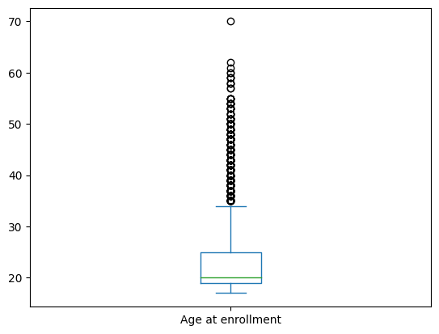

```python
student_data['Age at enrollment'].plot(kind='box')
```

The data suggests that most of the students are below the age of 35 and hence it would be beneficial to understand the dropout trends in that group of students, hence only selecting a student under 35 years of age.

```python
student_data = student_data[student_data['Age at enrollment'] < 35]
student_data.shape
```

```
(3241, 37)
```

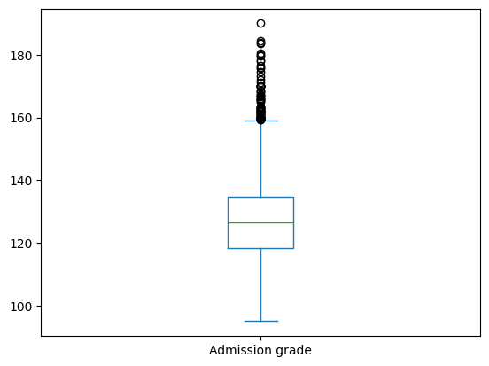

```python
student_data['Admission grade'].plot(kind='box')
```

```python
student_data = student_data[student_data['Admission grade'] < 160]
student_data.shape
```

```
(3154, 37)
```

Students having excellent admission grades are outliers and do not represent an average school student. Most of them are academically brilliant and in most cases have their education completely sponsored. As these groups of students are not at risk of dropping out, we are removing the outlier.

### Understanding Class Distributions

[output not shown]

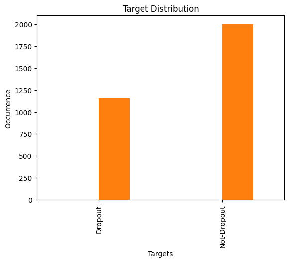

```python
unique_targets = student_data['Target'].unique().tolist()
class_distributions = dict()
for target in unique_targets:
  class_distributions[target] = student_data[student_data['Target'] == target]['Target'].count()
class_dist = pd.DataFrame({'target':class_distributions.keys(), 'occurrence':class_distributions.values()})
ax = class_dist.plot(kind='bar', title='Target Distribution', xlabel='Targets', ylabel='Occurrence', legend=False)
plt.xticks([0, 1], ['Dropout', 'Not-Dropout'])
```

```python
for target in unique_targets:
    print(target,' = ', round(int(class_dist[class_dist['target']== target]['occurrence'])*100/class_dist['occurrence'].sum(),2),'%')
```

```
1  =  36.68 %
0  =  63.32 %
```

The above distribution of targets clearly shows an imbalance in classes. The 'Graduate' class consists of almost 2/3 of the dataset, whereas 'Dropouts' only account for 1/3rd of the dataset. This can be considered as a case of moderate imbalance.

### Data Transformation and Dimensionality Reduction

```python
matrix = student_data.drop(columns=['Target'], axis=1).corr()
high_corr = abs(matrix) >=0.70  # looking at correlations higher than 0.70
cols = high_corr.columns.tolist()
for col in cols:
    temp = high_corr[high_corr[col] == True].index.tolist()
    temp.pop(temp.index(col))
    if len(temp) != 0:
        print(col,' has high corr with ',temp)
        print(matrix[col].loc[temp] , '\n\n\n')
```

```
Nationality  has high corr with  ['International']
International    0.808226
Name: Nationality, dtype: float64



Mother's occupation  has high corr with  ["Father's occupation"]
Father's occupation    0.881943
Name: Mother's occupation, dtype: float64



Father's occupation  has high corr with  ["Mother's occupation"]
Mother's occupation    0.881943
Name: Father's occupation, dtype: float64



International  has high corr with  ['Nationality']
Nationality    0.808226
Name: International, dtype: float64



Curricular units 1st sem (credited)  has high corr with  ['Curricular units 1st sem (enrolled)', 'Curricular units 2nd sem (credited)']
Curricular units 1st sem (enrolled)    0.753273
Curricular units 2nd sem (credited)    0.944374
Name: Curricular units 1st sem (credited), dtype: float64



Curricular units 1st sem (enrolled)  has high corr with  ['Curricular units 1st sem (credited)', 'Curricular units 1st sem (approved)', 'Curricular units 2nd sem (credited)', 'Curricular units 2nd sem (enrolled)']
Curricular units 1st sem (credited)    0.753273
Curricular units 1st sem (approved)    0.766535
Curricular units 2nd sem (credited)    0.735676
Curricular units 2nd sem (enrolled)    0.944765
Name: Curricular units 1st sem (enrolled), dtype: float64



```

[output cut: 42 more lines]

```


Curricular units 2nd sem (approved)  has high corr with  ['Curricular units 1st sem (approved)', 'Curricular units 2nd sem (enrolled)', 'Curricular units 2nd sem (grade)']
Curricular units 1st sem (approved)    0.915134
Curricular units 2nd sem (enrolled)    0.706276
Curricular units 2nd sem (grade)       0.791942
Name: Curricular units 2nd sem (approved), dtype: float64



Curricular units 2nd sem (grade)  has high corr with  ['Curricular units 1st sem (approved)', 'Curricular units 1st sem (grade)', 'Curricular units 2nd sem (approved)']
Curricular units 1st sem (approved)    0.721828
Curricular units 1st sem (grade)       0.848377
Curricular units 2nd sem (approved)    0.791942
Name: Curricular units 2nd sem (grade), dtype: float64
```

looking at the above results, we can identify features that are highly correlated. Highly correlated features do not provide any additional information, and so we can select one feature and drop the remaining features. Another approach is to merge similar features into a single features, and this is achieved via principal component analysis. We can see that all the sem 1 and sem 2 features are highly correlated, and hence we are only picking sem 1 and sem 2 grades and eliminate the remaining features. On further analysis, both sem1 ans sem 2 grades are also highly correlated; hence we can merge them into 1 feature called—'Academic PCA.' At first glance, a similar approach can be applied to the mother's and father's occupation as these two features are also highly correlated. the major difference is that these are categorical features whereas academic grades were non-categorical features. PCA approach is only suitable for non-categorical data.

```python
reduce_cols = ['Curricular units 1st sem (credited)', 'Curricular units 1st sem (enrolled)', 'Curricular units 1st sem (evaluations)', 'Curricular units 1st sem (approved)', 'Curricular units 1st sem (grade)', 'Curricular units 1st sem (without evaluations)', 'Curricular units 2nd sem (credited)', 'Curricular units 2nd sem (enrolled)', 'Curricular units 2nd sem (evaluations)', 'Curricular units 2nd sem (approved)', 'Curricular units 2nd sem (grade)', 'Curricular units 2nd sem (without evaluations)','International']
academic_data = student_data[['Curricular units 1st sem (grade)', 'Curricular units 2nd sem (grade)']]
scaler = StandardScaler()
scaler.fit(academic_data)
academic_data_scaled = scaler.transform(academic_data)
pca = PCA(n_components=1)
pca.fit(academic_data_scaled)
academic_pca = pca.transform(academic_data_scaled)
student_data.drop(reduce_cols, axis=1, inplace=True)
student_data.reset_index(drop=True, inplace=True)
academic_pca = pd.DataFrame(academic_pca)
academic_pca.rename(columns={0:'academic_pca'}, inplace=True)
student_data = student_data.merge(academic_pca, how='left', left_index=True, right_index=True)
student_data.head()
```

|  | Marital Status | Application mode | Application order | Course | Daytime/evening attendance | Previous qualification | Previous qualification (grade) | Nationality | Mother's qualification | Father's qualification | ... | Debtor | Tuition fees up to date | Gender | Scholarship holder | Age at enrollment | Unemployment rate | Inflation rate | GDP | Target | academic_pca |
| --- | --- | --- | --- | --- | --- | --- | --- | --- | --- | --- | --- | --- | --- | --- | --- | --- | --- | --- | --- | --- | --- |
| 0 | 1 | 17 | 5 | 171 | 1 | 1 | 122.0 | 1 | 19 | 12 | ... | 0 | 1 | 1 | 0 | 20 | 10.8 | 1.4 | 1.74 | 1 | 2.920916 |
| 1 | 1 | 15 | 1 | 9254 | 1 | 1 | 160.0 | 1 | 1 | 3 | ... | 0 | 0 | 1 | 0 | 19 | 13.9 | -0.3 | 0.79 | 0 | -0.925974 |
| 2 | 1 | 1 | 5 | 9070 | 1 | 1 | 122.0 | 1 | 37 | 37 | ... | 0 | 0 | 1 | 0 | 19 | 10.8 | 1.4 | 1.74 | 1 | 2.920916 |
| 3 | 1 | 17 | 2 | 9773 | 1 | 1 | 122.0 | 1 | 38 | 37 | ... | 0 | 1 | 0 | 0 | 20 | 9.4 | -0.8 | -3.12 | 0 | -0.674725 |
| 4 | 1 | 1 | 1 | 9500 | 1 | 1 | 142.0 | 1 | 19 | 38 | ... | 0 | 1 | 0 | 1 | 18 | 15.5 | 2.8 | -4.06 | 0 | -0.914650 |

5 rows × 25 columns

### Function for computing baseline accuracy

```python
from sklearn.dummy import DummyClassifier


def compute_baseline_accuracy(features: pd.DataFrame, tar: pd.DataFrame) -> None:
    # Create a ZeroR classifier (predicts the most frequent class)
    dummy_clf = DummyClassifier(strategy="most_frequent")
    dummy_clf.fit(features, tar)  # Reshape X to match scikit-learn input format

    # Predictions (always predicts 1 for Democrat)
    predictions = dummy_clf.predict(features)

    # Calculate accuracy (compare with your model's accuracy)
    baseline_accuracy = dummy_clf.score(features, tar)

    print(f"Predictions: {predictions}")
    print(f"Baseline Accuracy: {baseline_accuracy:.2f}")
```

## Balancing Classes

```python
X = student_data.drop(columns=['Target'])
y = student_data['Target']
X.name = 'UnBalanced_X'
y.name = 'UnBalanced_y'
```

### Technique 1 - Oversampling - SMOTE

```python
from imblearn.over_sampling import SMOTE
from collections import Counter
somte = SMOTE()
X_SMOTE, y_SMOTE = somte.fit_resample(X,y)
X_SMOTE.name = 'SMOTE_X'
y_SMOTE.name = 'SMOTE_y'

# Check the class distribution after SMOTE
print("Class distribution after SMOTE:", sorted(Counter(y_SMOTE).items()))
```

```
Class distribution after SMOTE: [(0, 1997), (1, 1997)]
```

```python
compute_baseline_accuracy(X_SMOTE, y_SMOTE)
```

```
Predictions: [0 0 0 ... 0 0 0]
Baseline Accuracy: 0.50
```

### Technique 2 - Oversampling - RandomOverSampler

```python
from imblearn.over_sampling import RandomOverSampler

# Initialize RandomOverSampler
ros = RandomOverSampler()

# Fit and transform the dataset
X_ROS, y_ROS = ros.fit_resample(X, y)
X_ROS.name = 'ROS_X'
y_ROS.name = 'ROS_y'

# Check the class distribution after Random Over Sampling
print("Class distribution after Random Over Sampling:", sorted(Counter(y_ROS).items()))
```

```
Class distribution after Random Over Sampling: [(0, 1997), (1, 1997)]
```

```python
compute_baseline_accuracy(X_ROS, y_ROS)
```

```
Predictions: [0 0 0 ... 0 0 0]
Baseline Accuracy: 0.50
```

### Technique 3 - Oversampling - ADASYN

```python
from imblearn.over_sampling import ADASYN

# Initialize ADASYN
adasyn = ADASYN()

# Fit and transform the dataset
X_ADASYN, y_ADASYN = adasyn.fit_resample(X, y)
X_ADASYN.name = 'ADASYN_X'
y_ADASYN.name = 'ADASYN_y'

# Check the class distribution after ADASYN
print("Class distribution after ADASYN:", sorted(Counter(y_ADASYN).items()))
```

```
Class distribution after ADASYN: [(0, 1997), (1, 2017)]
```

```python
compute_baseline_accuracy(X_ADASYN, y_ADASYN)
```

```
Predictions: [1 1 1 ... 1 1 1]
Baseline Accuracy: 0.50
```

### Technique 4 - Undersampling - RandomUnderSampler

```python
from imblearn.under_sampling import RandomUnderSampler
rus = RandomUnderSampler()
X_RUS, y_RUS = rus.fit_resample(X, y)
X_RUS.name = 'RUS_X'
y_RUS.name = 'RUS_y'


# Check the class distribution after Random Under Sampling
print("Class distribution after Random Under Sampling:", sorted(Counter(y_RUS).items()))
```

```
Class distribution after Random Under Sampling: [(0, 1157), (1, 1157)]
```

```python
compute_baseline_accuracy(X_RUS, y_RUS)
```

```
Predictions: [0 0 0 ... 0 0 0]
Baseline Accuracy: 0.50
```

## Creating Dataframe to store performance data for different models and datasets

```python
Datasets = {'Unbalanced': [X,y], 'SMOTE': [X_SMOTE,y_SMOTE], 'RandomOverSampler': [X_ROS,y_ROS], 'ADASYN': [X_ADASYN,y_ADASYN], 'RandomUnderSampler': [X_RUS,y_RUS]}
```

```python
model_names = ['LR_lasso', 'LR_Ridge', 'XGBoost', 'Random_Forest']
balancing = ['Unbalanced', 'SMOTE', 'RandomOverSampler', 'ADASYN', 'RandomUnderSampler']
performance_metrics = {
    'Accuracy': [np.nan, np.nan, np.nan, np.nan, np.nan],
    'Precision': [np.nan, np.nan, np.nan, np.nan, np.nan],
    'Recall': [np.nan, np.nan, np.nan, np.nan, np.nan],
    'F1': [np.nan, np.nan, np.nan, np.nan, np.nan],
}
models = dict()
models_rfe = dict()
for model_name in model_names:
    models[model_name] = pd.DataFrame(performance_metrics, index=balancing)
for model_name in model_names:
    models_rfe[model_name] = pd.DataFrame(performance_metrics, index=balancing)
```

## Feature Selection using Recursive Feature Elimination

### Rigde Regression

```python
variance = 0.001
best_accuracy = 0
X_features_ridge = list()
n_features = 0
random_state = 0
while n_features == 0:
    for data in Datasets.keys():
        X_data = Datasets[data][0]
        y_data = Datasets[data][1]
        X_features_rg, accuracy_rg = Helper.RFE_logistic_regression(X_data, y_data,variance_pct=variance, regression='l2', random_state=random_state)
        if (accuracy_rg >= best_accuracy*(1-variance)) and (3 <= len(X_features_rg) <= 10):
            best_accuracy = accuracy_rg
            X_features_ridge = X_features_rg
    if len(X_features_ridge) != 0:
        print(X_features_ridge)
        print('accuracy = ', best_accuracy, 'at variance = ', round(variance, 3))
        n_features = len(X_features_ridge)
    else:
        variance += 0.001
    if variance > 0.05:
        print("Could not reduce number of features significantly, try again")
        break
```

```
['Tuition fees up to date', 'Scholarship holder', 'academic_pca']
accuracy =  0.8115095913261051 at variance =  0.006
```

### Lasso Regression

```python
variance = 0.001
best_accuracy = 0
X_features_lasso = list()
n_features = 0
random_state = 0
while n_features == 0:
    for data in Datasets.keys():
        X_data = Datasets[data][0]
        y_data = Datasets[data][1]
        X_features_lr, accuracy_lr = Helper.RFE_logistic_regression(X_data, y_data, variance_pct=variance, regression='l1', random_state=random_state)
        if (accuracy_lr >= best_accuracy*(1-variance)) and (3 <= len(X_features_lr) <= 10):
            best_accuracy = accuracy_lr
            X_features_lasso = X_features_lr
    if len(X_features_lasso) != 0:
        print(X_features_lasso)
        print('accuracy = ', best_accuracy, 'at variance = ', round(variance, 3))
        n_features = len(X_features_lasso)
    else:
        variance += 0.001
    if variance > 0.05:
        print("Could not reduce number of features significantly, try again")
        break
```

```
['Tuition fees up to date', 'Scholarship holder', 'academic_pca']
accuracy =  0.8115095913261051 at variance =  0.012
```

Lasso and Ridge logistic regression methods for recursive feature elimination give very the same 3 featues, which suggest that they are the top 3 important features in this dataset.

```python
# Select features from RFE - logistic ridge
X_ridge = student_data[X_features_ridge]

# Select features from RFE - logistic lasso
X_lasso = student_data[X_features_lasso]

# Select features from correlation matrix
X_corr = student_data[['academic_pca','Age at enrollment', 'Tuition fees up to date','Scholarship holder', 'Debtor', 'Gender', 'Admission grade']]
```

## Logistic Regression—Using Correlation Features

```python
X = X_corr.copy()
```

### Lasso Regression

```
model =  LR_lasso 	dataset =  Unbalanced


accuracy after feature drop:  0.8447729672650475
Precision: 0.8727
Recall: 0.6818
F1: 0.7656
```

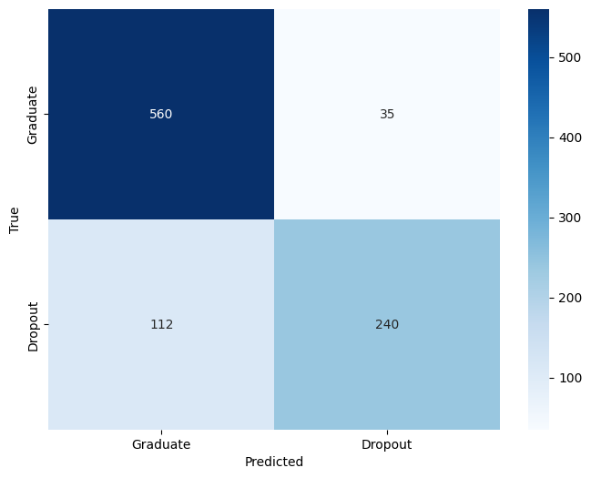

```
model =  LR_lasso 	dataset =  SMOTE


accuracy after feature drop:  0.8437170010559663
Precision: 0.8520
Recall: 0.6880
F1: 0.7613
```

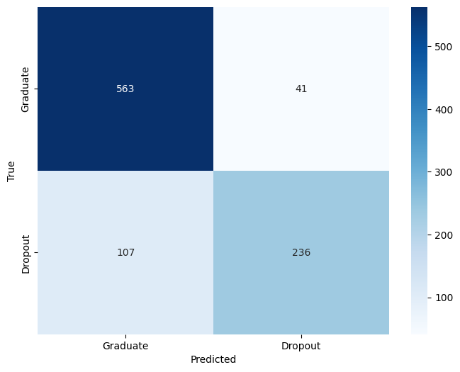

```
model =  LR_lasso 	dataset =  RandomOverSampler


accuracy after feature drop:  0.870116156282999
Precision: 0.9101
Recall: 0.7105
F1: 0.7980
```

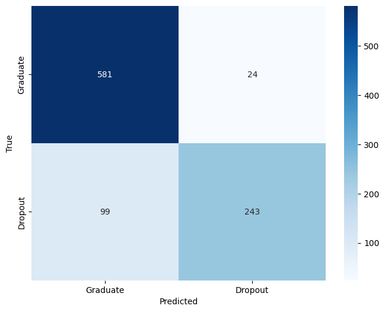

```
model =  LR_lasso 	dataset =  ADASYN


accuracy after feature drop:  0.8637803590285111
Precision: 0.8834
Recall: 0.7225
F1: 0.7949
```

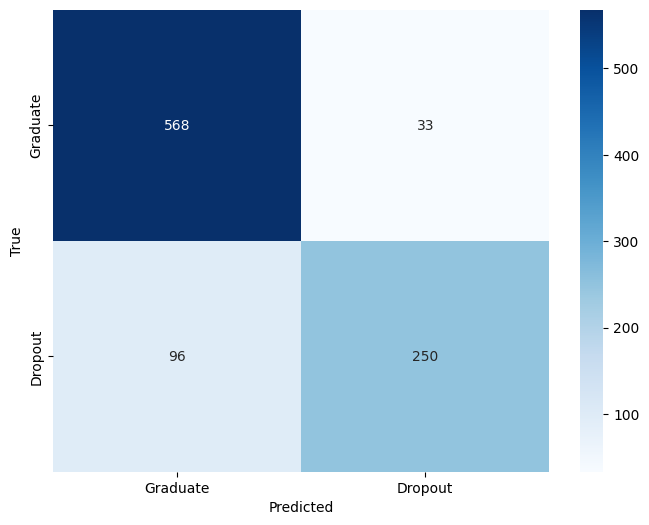

```
model =  LR_lasso 	dataset =  RandomUnderSampler


accuracy after feature drop:  0.8405491024287223
Precision: 0.8419
Recall: 0.6574
F1: 0.7383
```

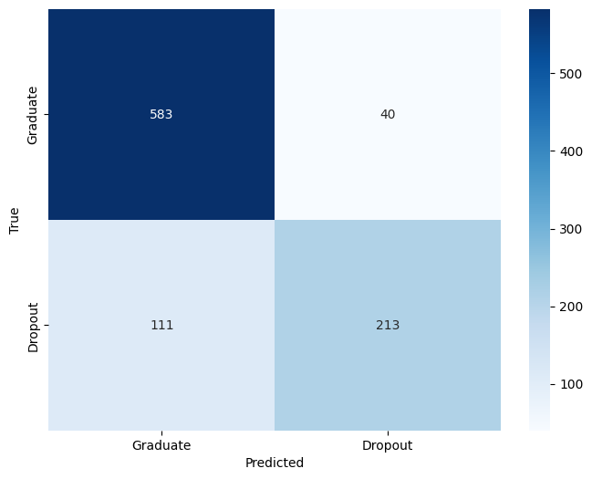

```python
model_name = 'LR_lasso'
for data in Datasets.keys():
    print('model = ', model_name, '\tdataset = ', data)
    models[model_name].loc[data, 'Accuracy'], models[model_name].loc[data, 'Precision'], models[model_name].loc[data, 'Recall'], models[model_name].loc[data, 'F1'] = Helper.logistic_regression(X, y, regression='l1', verbose=True)
```

### Ridge Regression

```
model =  LR_Ridge 	dataset =  Unbalanced


accuracy after feature drop:  0.8373812038014784
Precision: 0.8659
Recall: 0.6551
F1: 0.7459
```

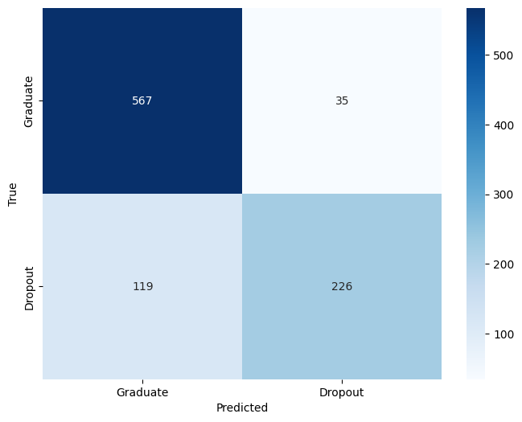

```
model =  LR_Ridge 	dataset =  SMOTE


accuracy after feature drop:  0.8352692713833157
Precision: 0.8707
Recall: 0.6524
F1: 0.7459
```

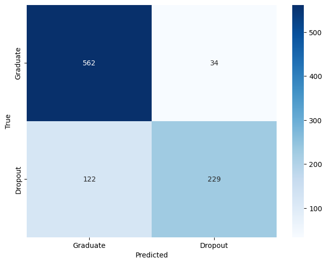

```
model =  LR_Ridge 	dataset =  RandomOverSampler


accuracy after feature drop:  0.853220696937698
Precision: 0.8419
Recall: 0.7046
F1: 0.7672
```

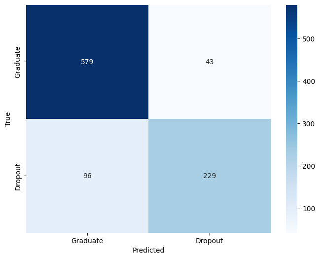

```
model =  LR_Ridge 	dataset =  ADASYN


accuracy after feature drop:  0.8542766631467793
Precision: 0.8648
Recall: 0.7085
F1: 0.7788
```

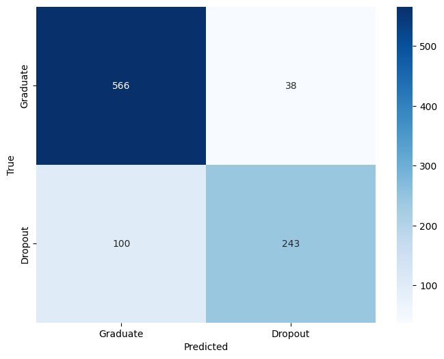

```
model =  LR_Ridge 	dataset =  RandomUnderSampler


accuracy after feature drop:  0.8458289334741288
Precision: 0.8235
Recall: 0.6957
F1: 0.7542
```

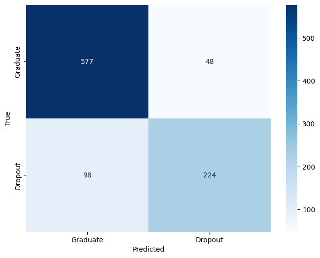

```python
model_name = 'LR_Ridge'
for data in Datasets.keys():
    print('model = ', model_name, '\tdataset = ', data)
    models_rfe[model_name].loc[data, 'Accuracy'], models_rfe[model_name].loc[data, 'Precision'], models_rfe[model_name].loc[data, 'Recall'], models_rfe[model_name].loc[data, 'F1'] = Helper.logistic_regression(X, y, regression='l2', verbose=True)
```

## Logistic Regression - Using RFE fetatures

```python
X = X_ridge.copy()
```

### Lasso Regression

```
model =  LR_lasso 	dataset =  Unbalanced


accuracy after feature drop:  0.8278775079197466
Precision: 0.9205
Recall: 0.6312
F1: 0.7488
```

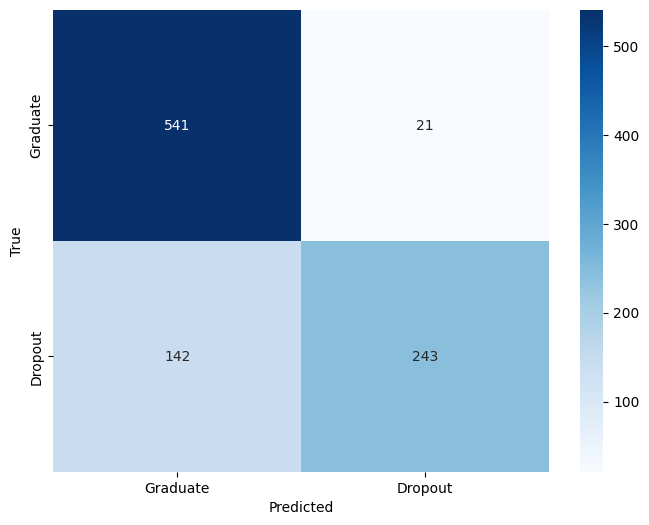

```
model =  LR_lasso 	dataset =  SMOTE


accuracy after feature drop:  0.8458289334741288
Precision: 0.9344
Recall: 0.6369
F1: 0.7575
```

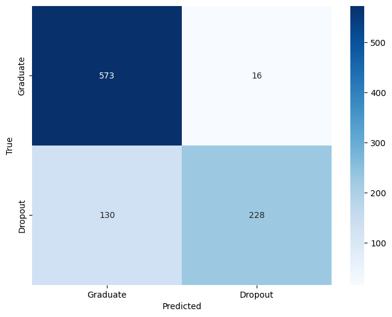

```
model =  LR_lasso 	dataset =  RandomOverSampler


accuracy after feature drop:  0.8553326293558606
Precision: 0.8803
Recall: 0.6826
F1: 0.7690
```

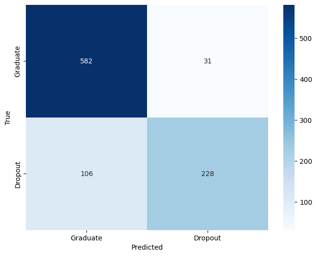

```
model =  LR_lasso 	dataset =  ADASYN


accuracy after feature drop:  0.8268215417106652
Precision: 0.8826
Recall: 0.6176
F1: 0.7267
```

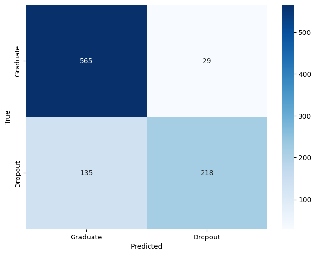

```
model =  LR_lasso 	dataset =  RandomUnderSampler


accuracy after feature drop:  0.8542766631467793
Precision: 0.9198
Recall: 0.6732
F1: 0.7774
```

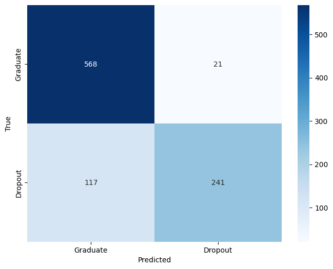

```python
model_name = 'LR_lasso'
for data in Datasets.keys():
    print('model = ', model_name, '\tdataset = ', data)
    models_rfe[model_name].loc[data, 'Accuracy'], models_rfe[model_name].loc[data, 'Precision'], models_rfe[model_name].loc[data, 'Recall'], models_rfe[model_name].loc[data, 'F1'] = Helper.logistic_regression(X, y, regression='l1', verbose=True)
```

### Ridge Regression

```
model =  LR_Ridge 	dataset =  Unbalanced


accuracy after feature drop:  0.8257655755015839
Precision: 0.8657
Recall: 0.5789
F1: 0.6939
```

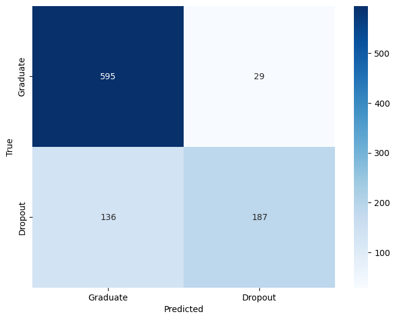

```
model =  LR_Ridge 	dataset =  SMOTE


accuracy after feature drop:  0.8247096092925026
Precision: 0.8903
Recall: 0.6011
F1: 0.7177
```

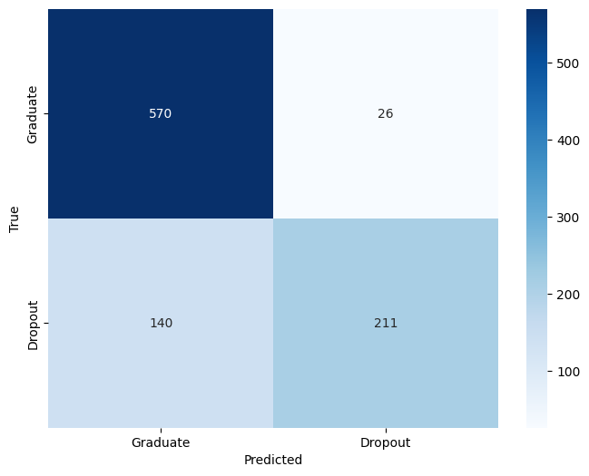

```
model =  LR_Ridge 	dataset =  RandomOverSampler


accuracy after feature drop:  0.8373812038014784
Precision: 0.9102
Recall: 0.6282
F1: 0.7433
```

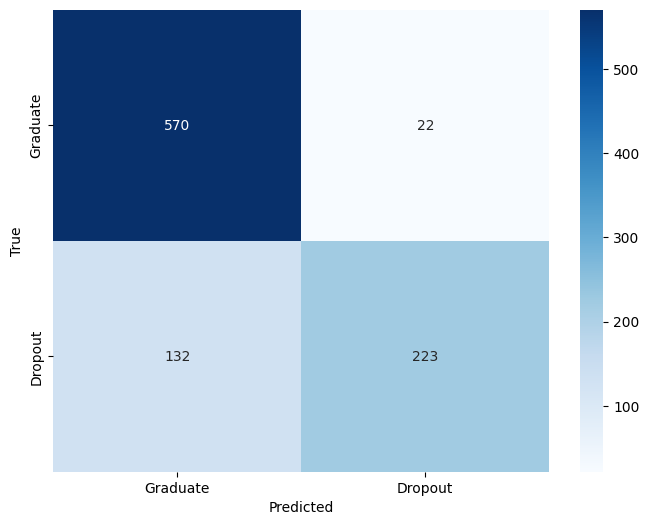

```
model =  LR_Ridge 	dataset =  ADASYN


accuracy after feature drop:  0.8405491024287223
Precision: 0.8765
Recall: 0.6377
F1: 0.7383
```

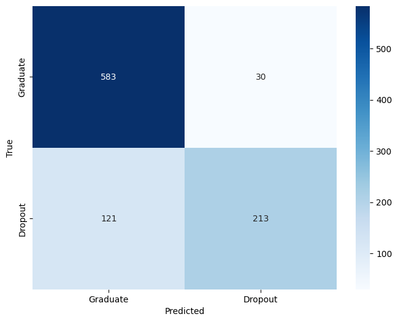

```
model =  LR_Ridge 	dataset =  RandomUnderSampler


accuracy after feature drop:  0.8426610348468849
Precision: 0.8782
Recall: 0.6353
F1: 0.7372
```

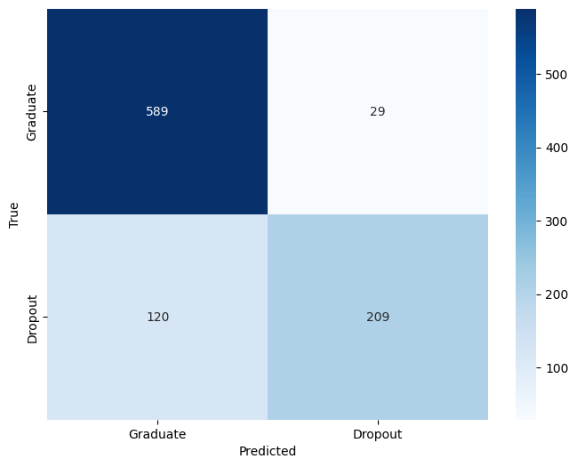

```python
model_name = 'LR_Ridge'
for data in Datasets.keys():
    print('model = ', model_name, '\tdataset = ', data)
    models[model_name].loc[data, 'Accuracy'], models[model_name].loc[data, 'Precision'], models[model_name].loc[data, 'Recall'], models[model_name].loc[data, 'F1'] = Helper.logistic_regression(X, y, regression='l2', verbose=True)
```

## Random Forest and XGBoost—Using Correlation features

```python
X = X_corr.copy()
```

### Random Forest

```python
X_train_rf, X_test_rf, y_train_rf, y_test_rf = train_test_split(X, y, test_size=0.3)
# Creating Classifier - Random Forest
accuracy_rf = dict()
rf_models = dict()
for trees in range(2, 30):
    clf_rf = RandomForestClassifier(n_estimators=trees)
    clf_rf.fit(X_train_rf,y_train_rf)
    rf_models[trees] = clf_rf
    y_pred_rf=clf_rf.predict(X_test_rf)
    accuracy_rf[trees] = accuracy_score(y_test_rf, y_pred_rf)
accuracy_rf = dict(sorted(accuracy_rf.items(),key=(lambda x: x[1]), reverse= True))
accuracy_rf
```

```
{14: 0.8553326293558606,
 8: 0.8500527983104541,
 19: 0.8479408658922915,
 18: 0.8458289334741288,
 21: 0.8458289334741288,
 29: 0.8458289334741288,
 9: 0.8447729672650475,
 23: 0.8447729672650475,
 28: 0.8447729672650475,
 6: 0.8426610348468849,
 10: 0.8426610348468849,
 24: 0.8426610348468849,
 27: 0.8426610348468849,
 26: 0.8416050686378036,
 20: 0.839493136219641,
 25: 0.839493136219641,
 15: 0.8384371700105596,
 16: 0.8384371700105596,
 13: 0.8373812038014784,
 17: 0.8321013727560718,
 5: 0.8310454065469906,
 12: 0.8310454065469906,
 11: 0.8289334741288279,
 7: 0.8278775079197466,
 22: 0.8268215417106652,
 4: 0.8204857444561774,
 2: 0.8141499472016895,
 3: 0.808870116156283}
```

```python
for model in accuracy_rf:
    y_pred_rf=rf_models[model].predict(X_test_rf)
    confusion_matrix_rf = pd.crosstab(y_test_rf, y_pred_rf, rownames=['Actual'], colnames=['Predicted'])
    print('Accuracy for i = {}: {} '.format(model, round(accuracy_score(y_test_rf, y_pred_rf), 4)))
    print(confusion_matrix_rf)
```

```
Accuracy for i = 14: 0.8553
Predicted    0    1
Actual
0          567   41
1           96  243
Accuracy for i = 8: 0.8501
Predicted    0    1
Actual
0          561   47
1           95  244
Accuracy for i = 19: 0.8479
Predicted    0    1
Actual
0          553   55
1           89  250
Accuracy for i = 18: 0.8458
Predicted    0    1
Actual
0          559   49
1           97  242
Accuracy for i = 21: 0.8458
Predicted    0    1
Actual
0          555   53
1           93  246
Accuracy for i = 29: 0.8458
Predicted    0    1
Actual
0          556   52
1           94  245
Accuracy for i = 9: 0.8448
Predicted    0    1
Actual
0          555   53
1           94  245
Accuracy for i = 23: 0.8448
Predicted    0    1
Actual
0          554   54
1           93  246
```

[output cut: 85 more lines]

```
Accuracy for i = 4: 0.8205
Predicted    0    1
Actual
0          552   56
1          114  225
Accuracy for i = 2: 0.8141
Predicted    0    1
Actual
0          574   34
1          142  197
Accuracy for i = 3: 0.8089
Predicted    0    1
Actual
0          525   83
1           98  241
```

```
Accuracy: 0.8712
Precision: 0.8350
Recall: 0.7726
F1 Score: 0.8026
```

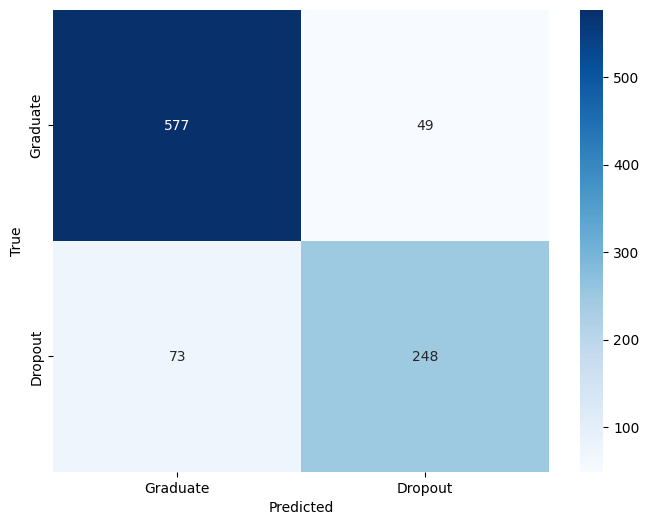

```
Accuracy: 0.8501
Precision: 0.8286
Recall: 0.7479
F1 Score: 0.7861
```

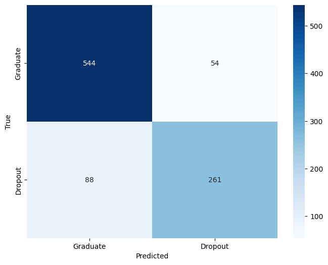

```
Accuracy: 0.8659
Precision: 0.8520
Recall: 0.7595
F1 Score: 0.8031
```

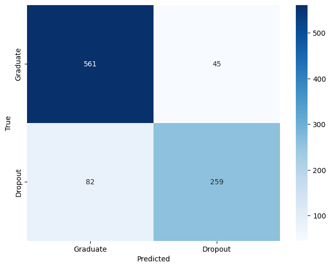

```
Accuracy: 0.8522
Precision: 0.8392
Recall: 0.7436
F1 Score: 0.7885
```

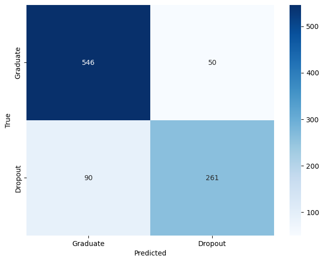

```
Accuracy: 0.8522
Precision: 0.8495
Recall: 0.7278
F1 Score: 0.7840
```

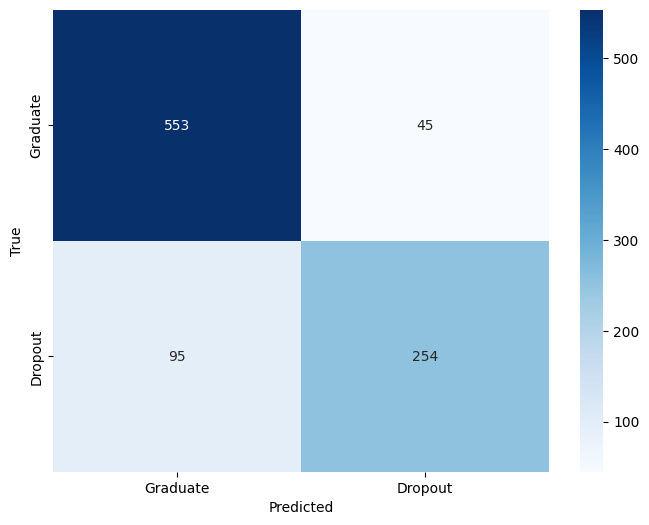

```python
model_name = 'Random_Forest'
n_trees = 19
max_depth = 10
for data in Datasets.keys():
    models[model_name].loc[data, 'Accuracy'], models[model_name].loc[data, 'Precision'], models[model_name].loc[data, 'Recall'],models[model_name].loc[data, 'F1'] = Helper.random_forest(X, y, n_estimators=n_trees, max_depth=max_depth, verbose=True)
```